# Support Vector Machine

Tomás Sánchez Grigioni

# Bibliotecas

Aqui incluimos las bibliotecas que vamos a necesitar utilizar para el desarrollo del trabajo

```r
library(tidyverse)
```

```r
library(caret)
```

```r
library(pROC)
```

# Constantes

Aqui decralamos las cosntantes que vamos a utilizar para el desarrollo del trabajo

```r
# Archivo
PATH_DATOS_IN <- "../data/bd_final_refactor.csv"
FILE_COLUMN_SEPARATOR <- ";"
FILE_DECIMAL_SEPARATOR <- "."

# Partición datos
SEED <- 1206
PORCENTAJE_TRAIN <- 0.7

# Variable respuesta
VAR_RESPUESTA <- "diagnostico_pro"

# Variables predictoras
VAR_PREDICTORA <- c("edad", "F0semitoneFrom27.5Hz_sma3nz_amean")

# Preprocesamiento
PRE_PROCESS_ESTANDARIZAR <- c("center", "scale")
CONTROL_CV <- "cv"
K_FOLD <- 10


# Entrenar el modelo
METODO_SVM_LINEAL <- "svmLinear"
METODO_SVM_RADIAL <- "svmRadial"
METODO_SVM_POLYNOMIAL <- "svmPoly"

C_MIN <- 0.001
C_MAX <- 2
```

# Importación Datos

```r
# Importamos datos
datos_crudos <- read.csv(PATH_DATOS_IN, sep = FILE_COLUMN_SEPARATOR, dec = FILE_DECIMAL_SEPARATOR, stringsAsFactors = TRUE)

# Verificamos que los tipos sean los correctos
glimpse(datos_crudos)
```

```
Rows: 2,218
Columns: 39
$ id                                             <int> 24665, 21472, 25155, 22829, 24848, 21417, 25652, 23500, 22216, 23967, 24861, 23331, 27236,...
$ d1                                             <dbl> 35.23343, 35.06466, 53.76691, 31.19639, 36.34814, 34.78511, 35.44090, 34.05800, 30.03747, ...
$ d2                                             <dbl> -178.85030, -177.20320, -178.88640, -197.15470, -117.80970, -191.45730, -146.54980, -128.1...
$ d3                                             <dbl> 0.374910, 0.379995, 0.359551, 0.325620, 0.271464, 0.395302, 0.387376, 0.299799, 0.359066, ...
$ d4                                             <dbl> 0.096570, 0.115948, 0.109389, 0.103234, 0.102776, 0.120893, 0.083093, 0.089153, 0.102191, ...
$ d5                                             <dbl> 0.032114, 0.024917, 0.058175, 0.069262, 0.005820, 0.016126, 0.064559, 0.040827, 0.055805, ...
$ edad                                           <int> 71, 48, 73, 50, 57, 51, 56, 52, 64, 36, 52, 72, 73, 61, 65, 67, 72, 83, 55, 71, 56, 65, 60...
$ es_cuidador                                    <fct> true, false, false, false, false, false, false, false, false, false, false, false, false, ...
$ dbs                                            <fct> false, NA, false, false, false, false, false, false, false, NA, false, false, false, false...
$ anio_diagnostico                               <int> 2011, NA, 2005, 2014, 2012, 2010, 2014, 1996, 2005, NA, 2014, 2011, 2013, 2003, 2010, 2005...
$ educ                                           <fct> HighSchool, HighSchool, HighSchool, HighSchool, College, Postgraduate, HighSchool, College...
$ empleo                                         <fct> Not Working, Working, Not Working, Working, Working, Working, Not Working, Not Working, Wo...
$ genero                                         <fct> Female, Male, Male, Male, Female, Male, Female, Female, Male, Female, Female, Female, Fema...
```

[output cut: 26 more lines]

# SVM Simple

## Análisis simple de datos

Vamos a verificar que los datos a usar no tengan nullos

```r
# Variables a usar en el modelo
variables <- c(VAR_PREDICTORA, VAR_RESPUESTA)

# Creamos el df que vamos a usar
# Como no vamos a hacer ningún tratamiento coinciden los dfs
datos <- datos_crudos %>% select(all_of(variables))

# Verificacion de la canitdad de nulos
datos %>%
  map_int(~ sum(is.na(.x)))
```

```
                             edad F0semitoneFrom27.5Hz_sma3nz_amean                   diagnostico_pro
                                0                                 0                                 0
```

Observamos que no hay ningún valor nulo,

Por último, vemos las medidas descriptivas

```r
summary(datos)
```

```
      edad       F0semitoneFrom27.5Hz_sma3nz_amean diagnostico_pro
 Min.   :35.00   Min.   :16.09                     false:1278
 1st Qu.:43.00   1st Qu.:23.90                     true : 940
 Median :53.00   Median :26.54
 Mean   :53.62   Mean   :27.59
 3rd Qu.:63.00   3rd Qu.:30.94
 Max.   :90.00   Max.   :53.77
```

Vamos a crear una función que realice el preprocesamiento de datos por nosotros. La idea es poder aplicar distintos procesamientos a un mismo df y probar los diferentes modelos.

```r
preprocesamiento <- function(df, var_target, lista_var_atribute, imputar_nulos = FALSE, imputar_outliers = FALSE,
                             metodo_escalar = NULL, metodo_dummies = NULL){

  # Primero dividimos los datos en dos dfs
  df_y <- df %>% select(all_of(var_target))
  df_x <- df %>% select(all_of(lista_var_atribute))

  if(imputar_nulos){
    # Código para imputar nulos
  }

  if(imputar_outliers){
    # Código para imputar outliers
  }

  if(!is.null(metodo_escalar)){
    # Código para escalar continuas
    df_x <- df_x %>%
      preProcess(method = metodo_escalar) %>%
      predict(df_x) %>%
      data.frame()
  }

  if(!is.null(metodo_dummies)) {
    # Código para generar dummies
    df_x <- dummyVars(~., df_x) %>%
      predict(df_x) %>%
      data.frame()
  }

  # Recodificamos la variable target
  df_y <- df_y %>% mutate(diagnostico_pro = fct_recode(diagnostico_pro, "-1" = "false", "1" = "true"))

  # Juntamos los df y devolvemos el resultado
  return(cbind(df_y, df_x))
}
```

Para nuestro caso solo vamos a escalar las variables numéricas, así que es el único parámetro a identificar

```r
# Aplicamos el preporcesamiento
df_svm_simple <- preprocesamiento(datos, VAR_RESPUESTA, VAR_PREDICTORA, metodo_escalar = PRE_PROCESS_ESTANDARIZAR)

# Observamos que esten centrados en 0 las numéricas
summary(df_svm_simple)
```

```
 diagnostico_pro      edad          F0semitoneFrom27.5Hz_sma3nz_amean
 -1:1278         Min.   :-1.51221   Min.   :-2.2845
 1 : 940         1st Qu.:-0.86267   1st Qu.:-0.7335
                 Median :-0.05074   Median :-0.2083
                 Mean   : 0.00000   Mean   : 0.0000
                 3rd Qu.: 0.76120   3rd Qu.: 0.6660
                 Max.   : 2.95341   Max.   : 5.1989
```

Dividimos los datos en train y test

```r
# Creamos los indices para hacer la partición
set.seed(SEED)
indices_train <- createDataPartition(df_svm_simple$diagnostico_pro, p = PORCENTAJE_TRAIN, list = FALSE) %>% as.vector()

# Dividimos los dfs
x_train <- df_svm_simple[indices_train, VAR_PREDICTORA]
x_test <- df_svm_simple[-indices_train, VAR_PREDICTORA]

y_train <- df_svm_simple[indices_train, VAR_RESPUESTA]
y_test <- df_svm_simple[-indices_train, VAR_RESPUESTA]
```

Ahora, creamos una función para entrenar a los modelos, teniendo la posibilidad de elegir el kernel

```r
entrenar_modelo <- function(y_train, x_train, method, tr_control = NULL, tune_grid = NULL){

  # Incialización de variables
  modelo <- NULL

  # Ajustamos el modelo a los datos
  if(is.null(tr_control) || is.null(tune_grid)){
    modelo <- train(y = y_train,
                  x = x_train,
                  method = method)
  } else {
   modelo <- train(y = y_train,
                  x = x_train,
                  method = method,
                  trControl = tr_control,
                  tuneGrid = tune_grid)
  }

  # Imprimios por pantalla el modelo
  print("----------------------------------------------")
  print("RESUMEN MODELO:")
  print(modelo)
  print("----------------------------------------------")

  # Retornamos el modelo
  return(modelo)
}
```

Creamso el train control a usar en los modelos.

```r
# Creamos el trControl
tr_control <- trainControl(method = CONTROL_CV, number = K_FOLD)
```

Ahora creamos los modelos, con diferentes kernerls

```r
# Kernel lineal
tune_grid_lineal <- expand.grid("C" = seq(C_MIN, C_MAX, 0.1))
svm_lineal <- entrenar_modelo(y_train, x_train, METODO_SVM_LINEAL, tr_control, tune_grid_lineal)
```

```
[1] "----------------------------------------------"
[1] "RESUMEN MODELO:"
Support Vector Machines with Linear Kernel

1553 samples
   2 predictor
   2 classes: '-1', '1'

No pre-processing
Resampling: Cross-Validated (10 fold)
Summary of sample sizes: 1398, 1397, 1399, 1398, 1397, 1397, ...
Resampling results across tuning parameters:

  C      Accuracy   Kappa
  0.001  0.6993335  0.3462824
  0.101  0.7598640  0.5109365
  0.201  0.7598640  0.5109365
  0.301  0.7598640  0.5109365
  0.401  0.7598640  0.5109365
  0.501  0.7598640  0.5109365
  0.601  0.7598640  0.5109365
  0.701  0.7598640  0.5109365
  0.801  0.7605050  0.5123605
  0.901  0.7605050  0.5123605
  1.001  0.7598640  0.5109365
  1.101  0.7598640  0.5109365
  1.201  0.7598640  0.5109365
  1.301  0.7598640  0.5109365
  1.401  0.7598640  0.5109365
  1.501  0.7598640  0.5109365
  1.601  0.7598640  0.5109365
  1.701  0.7598640  0.5109365
  1.801  0.7598640  0.5109365
  1.901  0.7598640  0.5109365

Accuracy was used to select the optimal model using the largest value.
The final value used for the model was C = 0.801.
[1] "----------------------------------------------"
```

```r
# Kerner radial
tune_grid_radial <- expand.grid("C" = seq(C_MIN, C_MAX, 0.1), "sigma" = seq(0, 2, 0.5))
svm_radial <- entrenar_modelo(y_train, x_train, METODO_SVM_RADIAL, tr_control, tune_grid_radial)
```

```
[1] "----------------------------------------------"
[1] "RESUMEN MODELO:"
Support Vector Machines with Radial Basis Function Kernel

1553 samples
   2 predictor
   2 classes: '-1', '1'

No pre-processing
Resampling: Cross-Validated (10 fold)
Summary of sample sizes: 1398, 1399, 1397, 1398, 1397, 1398, ...
Resampling results across tuning parameters:

  C      sigma  Accuracy   Kappa
  0.001  0.0    0.5763034  0.0000000
  0.001  0.5    0.5763034  0.0000000
  0.001  1.0    0.5763034  0.0000000
  0.001  1.5    0.5763034  0.0000000
  0.001  2.0    0.5763034  0.0000000
  0.101  0.0    0.5763034  0.0000000
  0.101  0.5    0.7578348  0.5099105
  0.101  1.0    0.7629795  0.5200997
  0.101  1.5    0.7571605  0.5085875
  0.101  2.0    0.7545840  0.5035382
  0.201  0.0    0.5763034  0.0000000
  0.201  0.5    0.7610523  0.5162016
  0.201  1.0    0.7603988  0.5147535
  0.201  1.5    0.7552250  0.5047347
  0.201  2.0    0.7539305  0.5019378
  0.301  0.0    0.5763034  0.0000000
  0.301  0.5    0.7616892  0.5170931
  0.301  1.0    0.7578140  0.5093979
  0.301  1.5    0.7545756  0.5033597
  0.301  2.0    0.7539305  0.5020268
  0.401  0.0    0.5763034  0.0000000
  0.401  0.5    0.7623385  0.5184706
  0.401  1.0    0.7552333  0.5043296
  0.401  1.5    0.7539346  0.5019876
  0.401  2.0    0.7519867  0.4983515
  0.501  0.0    0.5763034  0.0000000
```

[output cut: 63 more lines]

```
  1.701  2.0    0.7545674  0.5034444
  1.801  0.0    0.5763034  0.0000000
  1.801  0.5    0.7616892  0.5173226
  1.801  1.0    0.7532895  0.5001730
  1.801  1.5    0.7532811  0.5004990
  1.801  2.0    0.7545715  0.5034594
  1.901  0.0    0.5763034  0.0000000
  1.901  0.5    0.7616892  0.5173226
  1.901  1.0    0.7526401  0.4987256
  1.901  1.5    0.7545673  0.5031258
  1.901  2.0    0.7539305  0.5022442

Accuracy was used to select the optimal model using the largest value.
The final values used for the model were sigma = 0.5 and C = 0.801.
[1] "----------------------------------------------"
```

```r
# Kernel polynomial
#tune_grid_poly <- expand.grid("C" = seq(C_MIN, C_MAX, 0.1), "degree" = seq(0, 2, 0.5), "scale" = seq(0, 1, 0.05))
svm_poly <- entrenar_modelo(y_train, x_train, METODO_SVM_POLYNOMIAL)
```

```
[1] "----------------------------------------------"
[1] "RESUMEN MODELO:"
Support Vector Machines with Polynomial Kernel

1553 samples
   2 predictor
   2 classes: '-1', '1'

No pre-processing
Resampling: Bootstrapped (25 reps)
Summary of sample sizes: 1553, 1553, 1553, 1553, 1553, 1553, ...
Resampling results across tuning parameters:

  degree  scale  C     Accuracy   Kappa
  1       0.001  0.25  0.5741330  0.00000000
```

[output cut: 30 more lines]

Creamos una función para evaluar el modelo

```r
evaluar_nodelo <- function(modelo, y_test, x_test){

  # Generamos las predicciones
  y_pred <- predict(modelo, x_test)

  # Obtenemos las métricas
  print("----------------------------------------------")
  print("RESULTADO DE EVALUACIÓN:")
  print("\n")
  print(confusionMatrix(y_pred, y_test, positive = "1"))
  print("\n")
  print("----------------------------------------------")
}
```

Evaluamos los modelos usando la función definida

**NOTA**: no logre encontrar como hacer para que el predict devuelva la probabilidad en lugar de la clase predicha

```r
evaluar_nodelo(svm_lineal, y_test, x_test)
```

```
[1] "----------------------------------------------"
[1] "RESULTADO DE EVALUACIÓN:"
[1] "\n"
Confusion Matrix and Statistics

          Reference
Prediction  -1   1
        -1 294  69
        1   89 213

               Accuracy : 0.7624
                 95% CI : (0.7282, 0.7943)
    No Information Rate : 0.5759
    P-Value [Acc > NIR] : <2e-16

                  Kappa : 0.5181

 Mcnemar's Test P-Value : 0.1306

            Sensitivity : 0.7553
            Specificity : 0.7676
         Pos Pred Value : 0.7053
         Neg Pred Value : 0.8099
             Prevalence : 0.4241
         Detection Rate : 0.3203
   Detection Prevalence : 0.4541
      Balanced Accuracy : 0.7615

       'Positive' Class : 1

[1] "\n"
[1] "----------------------------------------------"
```

```r
evaluar_nodelo(svm_radial, y_test, x_test)
```

```
[1] "----------------------------------------------"
[1] "RESULTADO DE EVALUACIÓN:"
[1] "\n"
Confusion Matrix and Statistics

          Reference
Prediction  -1   1
        -1 286  68
        1   97 214

               Accuracy : 0.7519
                 95% CI : (0.7172, 0.7843)
    No Information Rate : 0.5759
    P-Value [Acc > NIR] : < 2e-16

                  Kappa : 0.4988

 Mcnemar's Test P-Value : 0.02927

            Sensitivity : 0.7589
            Specificity : 0.7467
         Pos Pred Value : 0.6881
         Neg Pred Value : 0.8079
             Prevalence : 0.4241
         Detection Rate : 0.3218
   Detection Prevalence : 0.4677
      Balanced Accuracy : 0.7528

       'Positive' Class : 1

[1] "\n"
[1] "----------------------------------------------"
```

```r
evaluar_nodelo(svm_poly, y_test, x_test)
```

```
[1] "----------------------------------------------"
[1] "RESULTADO DE EVALUACIÓN:"
[1] "\n"
Confusion Matrix and Statistics

          Reference
Prediction  -1   1
        -1 297  73
        1   86 209

               Accuracy : 0.7609
                 95% CI : (0.7266, 0.7929)
    No Information Rate : 0.5759
    P-Value [Acc > NIR] : <2e-16

                  Kappa : 0.5135

 Mcnemar's Test P-Value : 0.3413

            Sensitivity : 0.7411
            Specificity : 0.7755
         Pos Pred Value : 0.7085
         Neg Pred Value : 0.8027
             Prevalence : 0.4241
         Detection Rate : 0.3143
   Detection Prevalence : 0.4436
      Balanced Accuracy : 0.7583

       'Positive' Class : 1

[1] "\n"
[1] "----------------------------------------------"
```

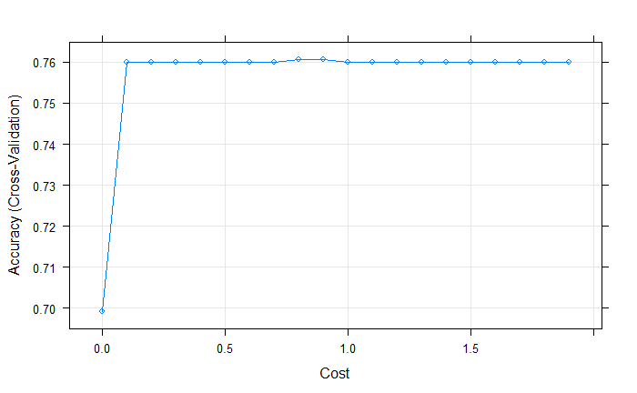

```r
plot(svm_lineal)
```